# Objective 2

Ahmed Awadallah

2022-07-30

## Complex Logistic Regression

Strategy: Expand upon the simple logistic model by adding new terms and interactions

Final Model: fracture~ age + height + tan(harmonic_height) + tan(harmonic_height):bmi + bmi + bmi:bonemed + momfrac+ armassist+ raterisk+ bonemed+ bonemed_fu + bonetreat

#### ROC Plot

The following is the ROC plot for the model. The AUC metric will be shown at the end in the metric comparison DF.

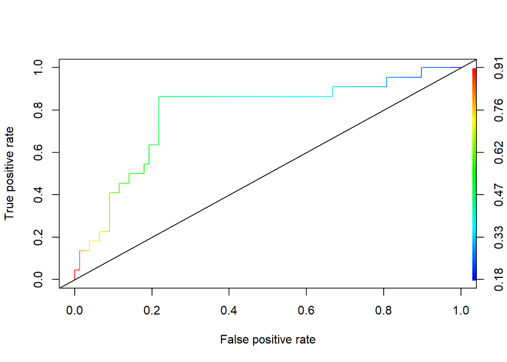

#### Threshold Plot

This is the plot used to select the threshold that maximize the f1 score for the model

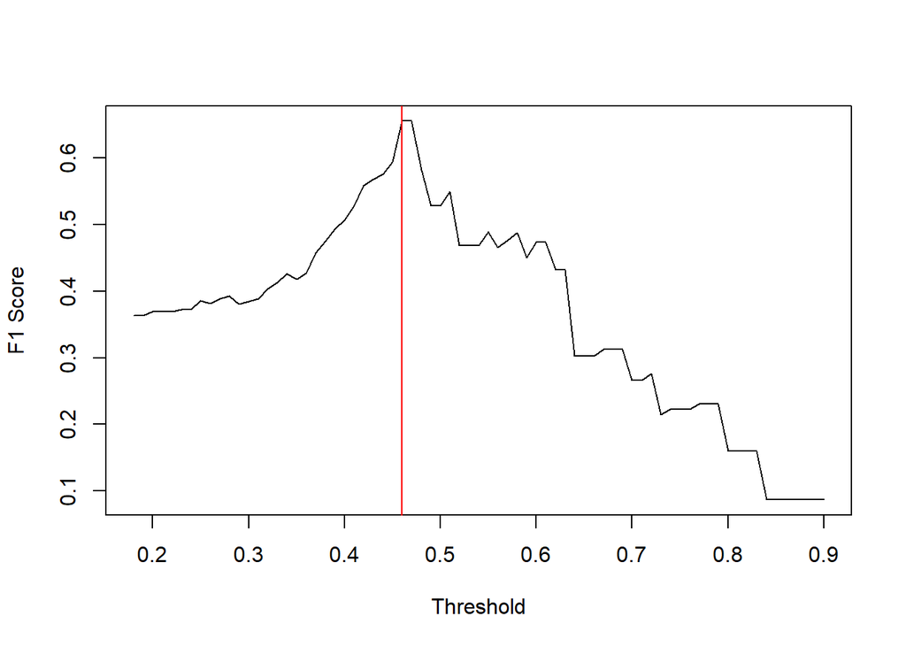

## PCA and QDA

Strategy: Build a QDA model with principle components for the same prediction task.

#### Principle Component Interpretation

PC1 appears to show something about age and fracscore

PC2 focuses more on physician, height and BMI

PC3 is physician and BMI

PC4 is physician, height, BMI, and fracscore

PC5 is age and fracscore again

Overall there is quite a bit of redundancy especially from PC4 and PC5. Hard to say what these are exactly representing overall.

```
## Standard deviations (1, .., p=5):
## [1] 1.4076951 1.0834468 0.9990694 0.8542180 0.3416278
##
## Rotation (n x k) = (5 x 5):
##                  PC1        PC2         PC3        PC4         PC5
## phy_id    -0.1202678  0.5698522 -0.63604865 0.50518157  0.03221542
## age       -0.6727259 -0.1754806  0.06350020 0.07231592  0.71230934
## height     0.2880231 -0.6145648 -0.02081417 0.73253371  0.04810302
## bmi        0.1074734  0.5045206  0.75108311 0.39455573  0.11877862
## fracscore -0.6621690 -0.1106528  0.16386208 0.21744454 -0.68931511
```

#### ROC

The following is the ROC plot for the model. The AUC metric will be shown at the end in the metric comparison DF.

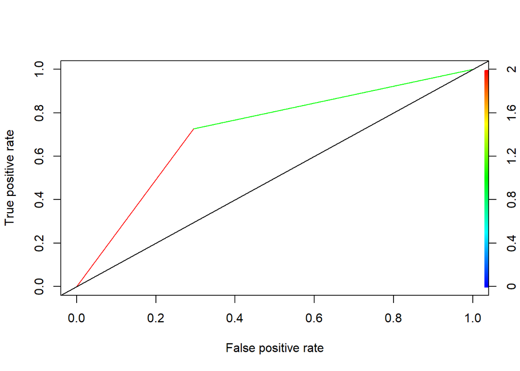

## Random Forest

Strategy: Use a random forest for the prediction task. Plan is to give the model all the features present in the dataset as random forest has its own innate feature selection. Perhaps it picks something out I couldn’t see.

#### Optimal Depth Plot

This is how the depth parameter is optimized. Forest classifiers are trained from some minimum depth up to some maximum depth. The depth that gave the best F1 score is then selected. The following is a plot visualizing the results.

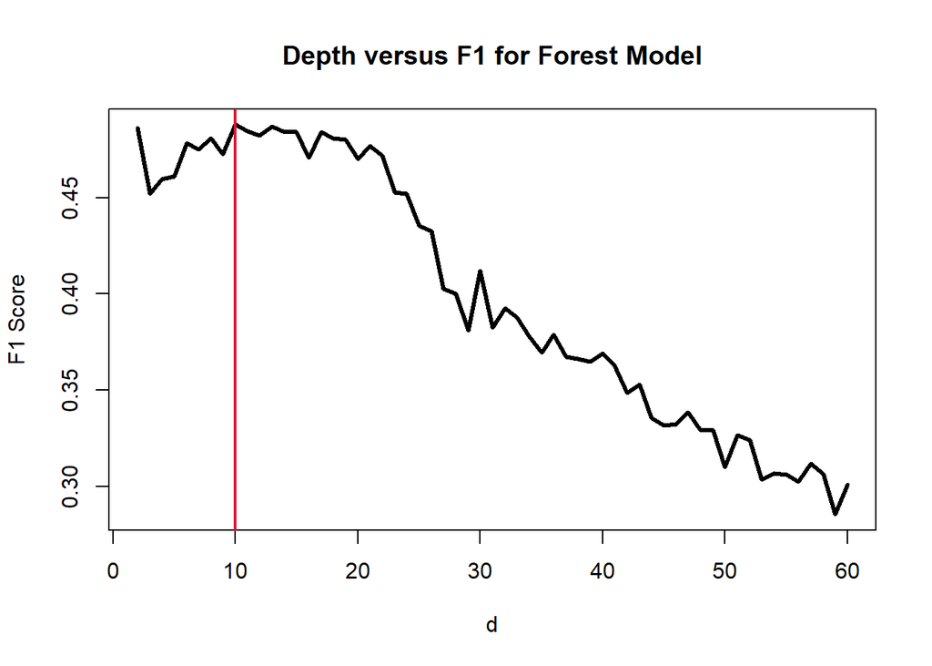

#### ROC

The following is the ROC plot for the model. The AUC metric will be shown at the end in the metric comparison DF.

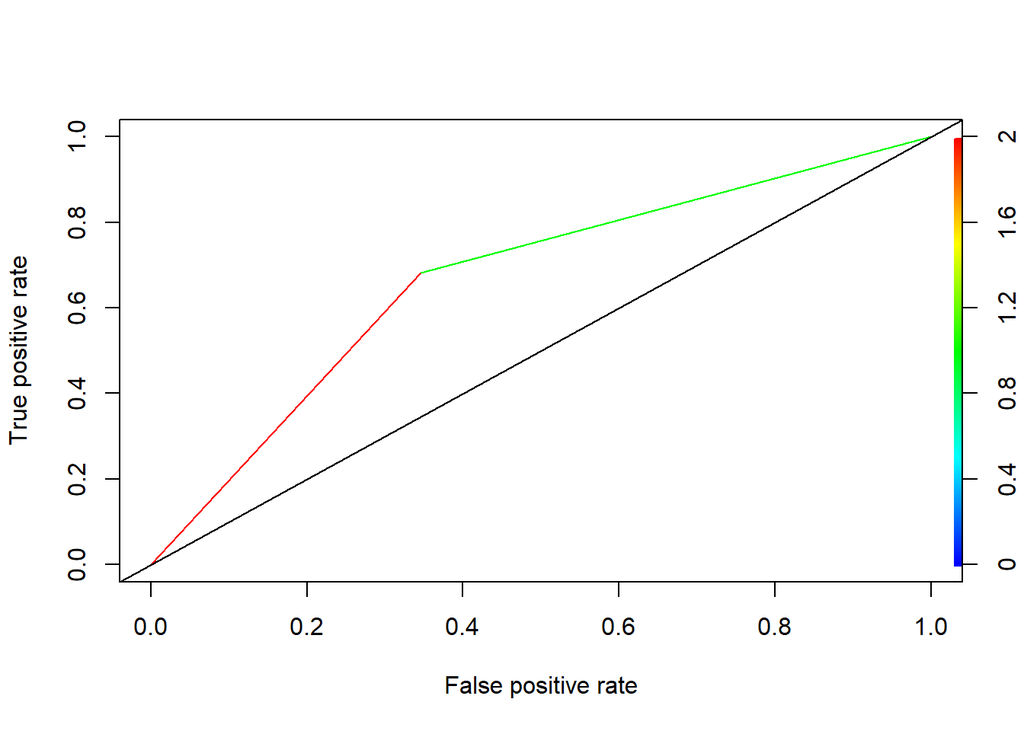

## Final Comparison

As we can see the complex logistic regression model did the best, followed by PCA+QDA then random forest.

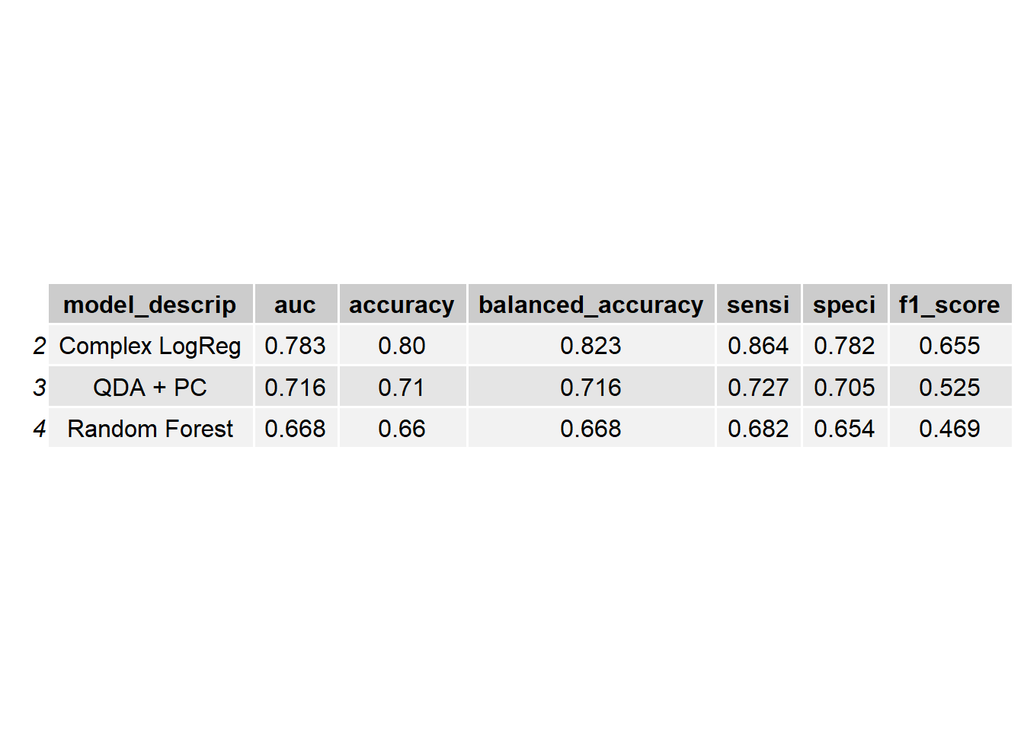